# Projet Actuariat

#### Exécution sur nos données freMPL2

Attention, les valeurs doivent être numériques.

On va donc convertir nos valeurs en numérique :

```r
freMPL2$LicAge <- as.numeric(freMPL2$LicAge)
freMPL2$DrivAge <- as.numeric(freMPL2$DrivAge)
freMPL2$BonusMalus <- as.numeric(freMPL2$BonusMalus)
freMPL2$RiskVar <- as.numeric(freMPL2$RiskVar)
freMPL2$ClaimAmount <- as.numeric(freMPL2$ClaimAmount)
```

```r
library("FactoMineR")
library("factoextra") # Pour la visualisation
```

```r
freMPL2.active <- freMPL2[,c(1:2,9,11, 18:19)]
freMPL2.pca <- PCA(freMPL2.active, graph = FALSE)
```

Affichage du résultat :

```r
get_eigenvalue(freMPL2.pca)
```

```
##       eigenvalue variance.percent cumulative.variance.percent
## Dim.1 2.31520784        38.586797                    38.58680
## Dim.2 1.02853013        17.142169                    55.72897
## Dim.3 0.99649119        16.608187                    72.33715
## Dim.4 0.96366164        16.061027                    88.39818
## Dim.5 0.62299351        10.383225                    98.78141
## Dim.6 0.07311569         1.218595                   100.00000
```

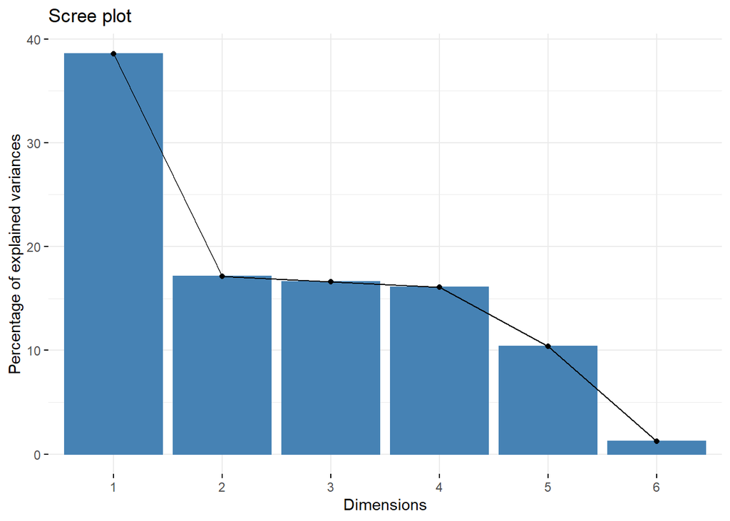

```r
fviz_eig(freMPL2.pca)
```

utilisation de cos2 pour juger de la qualité de la représentation :

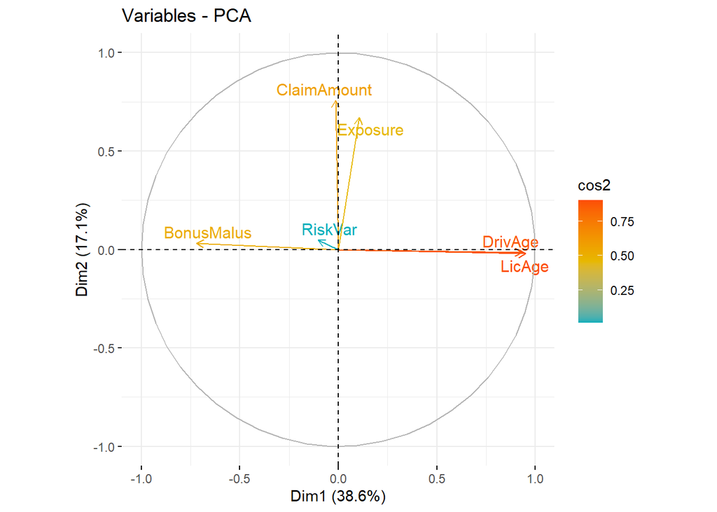

```r
fviz_pca_var(freMPL2.pca, col.var = "cos2",
             gradient.cols = c("#00AFBB", "#E7B800", "#FC4E07"),
             repel = TRUE # Évite le chevauchement de texte
             )
```

contribution des colonnes aux dimensions :

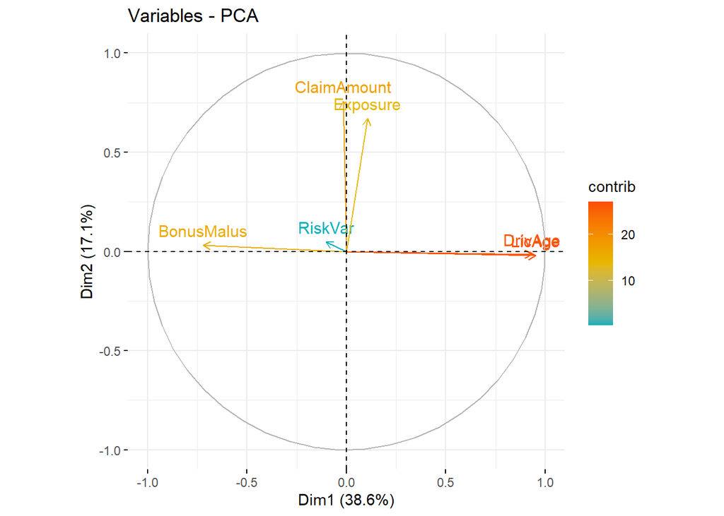

```r
fviz_pca_var(freMPL2.pca, col.var = "contrib",
             gradient.cols = c("#00AFBB", "#E7B800", "#FC4E07")
             )
```

Description des dimensions

Dans les sections précédentes, nous avons décrit comment mettre en évidence les variables en fonction de leurs contributions aux composantes principales.

Notez également que la fonction dimdesc() [dans FactoMineR], pour dimension description (en anglais), peut être utilisée pour identifier les variables les plus significativement associées avec une composante principale donnée . Elle peut être utilisée comme suit:

```r
freMPL2.desc <- dimdesc(freMPL2.pca, axes = c(1,2), proba = 0.05)
head(freMPL2.desc)
```

[output not shown]

###### AFC

L’ analyse factorielle des correspondances est une extension de l’analyse en composantes principales pour analyser l’association entre deux variables qualitatives (ou catégorielles). L’AFC permet de résumer et de visualiser l’information contenue dans le tableau de contingence formé par les deux variables catégorielles. Le tableau de contingence contient les fréquences formées par les deux variables.

```r
library ("FactoMineR")
freMPL2.ca <- CA (freMPL2.active)
```

[figure not shown]

```r
get_eigenvalue(freMPL2.ca)
```

```
##         eigenvalue variance.percent cumulative.variance.percent
## Dim.1 0.8368987402      88.15185447                    88.15185
## Dim.2 0.1044266947      10.99942723                    99.15128
## Dim.3 0.0053632523       0.56491976                    99.71620
## Dim.4 0.0021692873       0.22849443                    99.94470
## Dim.5 0.0005250479       0.05530412                   100.00000
```

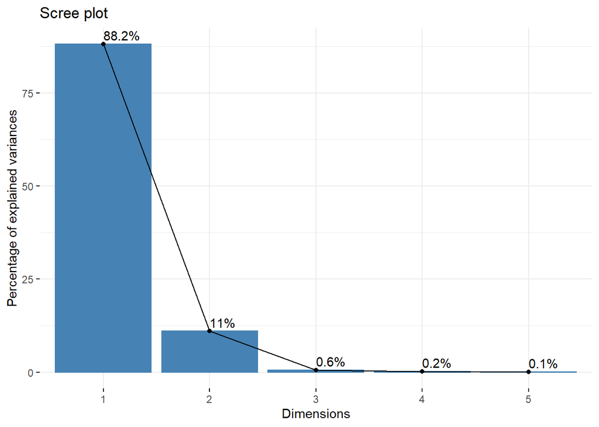

```r
fviz_screeplot (freMPL2.ca, addlabels = TRUE)
```

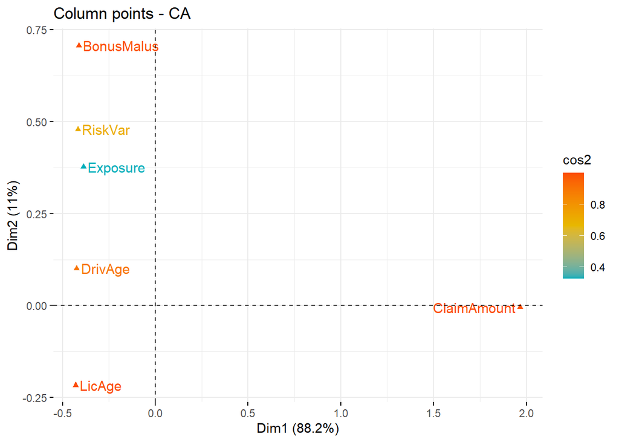

```r
fviz_ca_col (freMPL2.ca, col.col = "cos2",
             gradient.cols = c("#00AFBB", "#E7B800", "#FC4E07"),
             repel = TRUE)
```

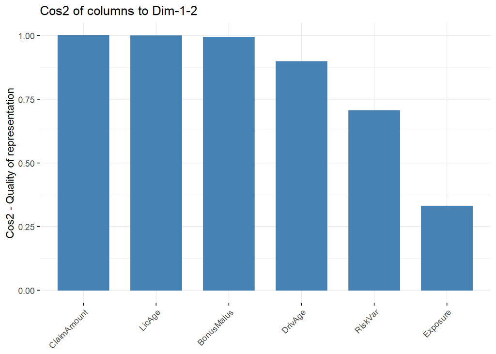

```r
fviz_cos2 (freMPL2.ca, choice = "col", axes = 1:2)
```

```r
res.desc <- dimdesc(freMPL2.ca, axes = c(1, 2))
res.desc[[1]]$col
```

```
##                  coord
## LicAge      -0.4297012
## DrivAge     -0.4235388
## RiskVar     -0.4177907
## BonusMalus  -0.4107983
## Exposure    -0.3880433
## ClaimAmount  1.9675625
```

# GLM

```r
#calibration d’une loi de Poisson
fpois <- glm(RiskVar~DrivAge+VehAge+VehClass+VehBody+VehEnergy, offset=log(Exposure), family=poisson("log"), data=freMPL2)
summary(fpois)
```

```
##
## Call:
## glm(formula = RiskVar ~ DrivAge + VehAge + VehClass + VehBody +
##     VehEnergy, family = poisson("log"), data = freMPL2, offset = log(Exposure))
##
## Deviance Residuals:
##     Min       1Q   Median       3Q      Max
## -7.9745  -1.7698   0.2224   2.7176  13.2888
##
## Coefficients:
##                         Estimate Std. Error z value Pr(>|z|)
## (Intercept)            3.515e+00  1.210e-02 290.407  < 2e-16 ***
## DrivAge               -2.799e-03  8.888e-05 -31.488  < 2e-16 ***
## VehAge1               -5.541e-02  6.103e-03  -9.079  < 2e-16 ***
## VehAge10+              9.702e-02  4.991e-03  19.437  < 2e-16 ***
## VehAge2               -5.895e-02  6.039e-03  -9.762  < 2e-16 ***
## VehAge3                1.043e-02  6.193e-03   1.685 0.092013 .
## VehAge4                6.832e-03  6.226e-03   1.097 0.272487
## VehAge5                4.730e-02  6.338e-03   7.463 8.44e-14 ***
## VehAge6-7              3.468e-02  5.847e-03   5.932 2.99e-09 ***
## VehAge8-9              6.245e-02  5.815e-03  10.739  < 2e-16 ***
## VehClassA              1.008e-02  8.825e-03   1.142 0.253440
## VehClassB              2.338e-02  7.879e-03   2.968 0.003000 **
## VehClassH             -5.229e-02  8.376e-03  -6.243 4.30e-10 ***
## VehClassM1             3.697e-02  7.786e-03   4.748 2.06e-06 ***
## VehClassM2             1.873e-02  8.196e-03   2.285 0.022285 *
## VehBodymicrovan        9.029e-02  1.042e-02   8.666  < 2e-16 ***
## VehBodyautobus         8.086e-03  2.049e-02   0.395 0.693148
## VehBodycoupé           3.463e-02  9.953e-03   3.480 0.000502 ***
## VehBodyautre microvan  6.972e-03  9.894e-03   0.705 0.481050
## VehBodyberline         4.838e-02  7.617e-03   6.353 2.12e-10 ***
## VehBodySUV             2.242e-02  9.951e-03   2.253 0.024253 *
## VehBodybreak           1.919e-02  9.526e-03   2.015 0.043946 *
## VehBodycamionnette    -3.745e-02  1.021e-02  -3.667 0.000245 ***
## VehEnergyGPL           7.207e-01  1.669e-01   4.319 1.57e-05 ***
## VehEnergyélectrique   -4.001e-01  1.314e-01  -3.045 0.002324 **
## VehEnergyessence      -6.305e-02  3.118e-03 -20.222  < 2e-16 ***
## ---
## Signif. codes:  0 '***' 0.001 '**' 0.01 '*' 0.05 '.' 0.1 ' ' 1
##
## (Dispersion parameter for poisson family taken to be 1)
##
##     Null deviance: 521321  on 47496  degrees of freedom
## Residual deviance: 516924  on 47471  degrees of freedom
## AIC: 723959
##
## Number of Fisher Scoring iterations: 5
```

```r
#calibration d’une loi Poisson sur-dispersée
fpois2 <- glm(RiskVar~DrivAge+VehAge+VehClass+VehBody+VehEnergy, offset=log(Exposure), family=quasipoisson("log"), data=freMPL2)
summary(fpois2)
```

```
##
## Call:
## glm(formula = RiskVar ~ DrivAge + VehAge + VehClass + VehBody +
##     VehEnergy, family = quasipoisson("log"), data = freMPL2,
##     offset = log(Exposure))
##
## Deviance Residuals:
##     Min       1Q   Median       3Q      Max
## -7.9745  -1.7698   0.2224   2.7176  13.2888
##
## Coefficients:
##                         Estimate Std. Error t value Pr(>|t|)
## (Intercept)            3.5150786  0.0698155  50.348  < 2e-16 ***
## DrivAge               -0.0027987  0.0005127  -5.459 4.81e-08 ***
## VehAge1               -0.0554086  0.0352004  -1.574 0.115474
## VehAge10+              0.0970155  0.0287893   3.370 0.000753 ***
## VehAge2               -0.0589466  0.0348309  -1.692 0.090583 .
## VehAge3                0.0104348  0.0357222   0.292 0.770205
## VehAge4                0.0068320  0.0359108   0.190 0.849115
## VehAge5                0.0472995  0.0365552   1.294 0.195699
## VehAge6-7              0.0346833  0.0337227   1.028 0.303727
## VehAge8-9              0.0624515  0.0335435   1.862 0.062636 .
## VehClassA              0.0100788  0.0509043   0.198 0.843050
## VehClassB              0.0233825  0.0454447   0.515 0.606886
## VehClassH             -0.0522911  0.0483134  -1.082 0.279111
## VehClassM1             0.0369664  0.0449084   0.823 0.410427
## VehClassM2             0.0187327  0.0472769   0.396 0.691934
## VehBodymicrovan        0.0902890  0.0600976   1.502 0.133007
## VehBodyautobus         0.0080860  0.1181992   0.068 0.945460
## VehBodycoupé           0.0346315  0.0574060   0.603 0.546331
## VehBodyautre microvan  0.0069717  0.0570701   0.122 0.902773
## VehBodyberline         0.0483842  0.0439318   1.101 0.270751
## VehBodySUV             0.0224200  0.0573957   0.391 0.696079
## VehBodybreak           0.0191920  0.0549484   0.349 0.726886
## VehBodycamionnette    -0.0374459  0.0588941  -0.636 0.524899
## VehEnergyGPL           0.7206873  0.9625394   0.749 0.454020
## VehEnergyélectrique   -0.4000731  0.7577335  -0.528 0.597511
## VehEnergyessence      -0.0630509  0.0179840  -3.506 0.000455 ***
## ---
## Signif. codes:  0 '***' 0.001 '**' 0.01 '*' 0.05 '.' 0.1 ' ' 1
##
## (Dispersion parameter for quasipoisson family taken to be 33.2696)
##
##     Null deviance: 521321  on 47496  degrees of freedom
## Residual deviance: 516924  on 47471  degrees of freedom
## AIC: NA
##
## Number of Fisher Scoring iterations: 5
```

# Annexes

## Affichage de l’implementation de la fonction nettoyage_dataframe :

```
nettoyage_dataframe <- function(dt){

  # Suppression des données des individus assurés moins d'un jour (Exposure)
  dt <- subset(dt,dt$Exposure>1/365.25)

  # Modification des données des individus ayant un ClaimAmount négatif
  dt <- subset(dt,dt$ClaimAmount>=0)

  # Suppression de la colonne associée au sexe de la personne
  dt <- dt[,-6]

  # Réduction du nombre de catégories socioprofessionnels
  levels(dt$SocioCateg) <- c(levels(dt$SocioCateg), "CSP4", "CSP6",
                                    "CSP9")
  for (i in 1:dim(dt)[1]){
    if (dt$SocioCateg[i]%in%c("CSP1","CSP16","CSP18","CSP19")){
      dt$SocioCateg[i]<-"CSP1"
      }
    if (dt$SocioCateg[i]%in%c("CSP2", "CSP20", "CSP21", "CSP22", "CSP23",
                                     "CSP25", "CSP26","CSP27", "CSP28")){
      dt$SocioCateg[i]<-"CSP2"
      }
    if (dt$SocioCateg[i]%in%c("CSP3", "CSP30", "CSP31", "CSP32", "CSP33",
                                     "CSP35", "CSP36","CSP37", "CSP38", "CSP39")){
      dt$SocioCateg[i]<-"CSP3"
      }
    if (dt$SocioCateg[i]%in%c("CSP40", "CSP41", "CSP42", "CSP43", "CSP46",
                                     "CSP47", "CSP48","CSP49")){
      dt$SocioCateg[i]<-"CSP4"
      }
    if (dt$SocioCateg[i]%in%c("CSP5", "CSP50", "CSP51", "CSP55", "CSP56",
                                     "CSP57", "CSP59")){
      dt$SocioCateg[i]<-"CSP5"
      }
    if (dt$SocioCateg[i]%in%c("CSP6", "CSP60", "CSP61", "CSP62", "CSP63",
                                     "CSP65", "CSP66")){
      dt$SocioCateg[i]<-"CSP6"
      }
    if (dt$SocioCateg[i]%in%c("CSP7", "CSP70", "CSP73", "CSP74", "CSP77")){
      dt$SocioCateg[i]<-"CSP7"
```

[output cut: 59 more lines]

```
      dt$VehEnergy[dt$VehEnergy == "eletric"]<-"électrique"
      dt$VehEnergy <- droplevels(dt$VehEnergy)
      }
    # Garage
    if (colnames(dt)[i]=="Garage"){
      levels(dt$Garage) <- c(levels(dt$Garage), "aucun", "garage indépendant",
                                    "concessionnaire")
      dt$Garage[dt$Garage == "None"]<-"aucun"
      dt$Garage[dt$Garage == "Private garage"]<-"garage indépendant"
      dt$Garage[dt$Garage == "Collective garage"]<-"concessionnaire"
      dt$Garage <- droplevels(dt$Garage)
    }
  }
  return (dt)
}
```

[output not shown]